# SDM Benchmark Study Part 7: Fitting and Testing Inhomogeneous Poisson Process Models with Updated Test Data

Benton Tripp

2023-10-26

## Overview

In [part 5](https://benton-tripp.github.io/posts/2023-10-13-sdm-benchmark-study-part-5-fitting-and-testing-ipp-models.html) of the study, a first attempt was made to fit IPP models to the data. Although the models are meant to serve as a baseline, the models had very poor performance. In an attempt to improve the results, several changes were made to the pseudo-absence selection process (see [part 6](https://benton-tripp.github.io/posts/2023-10-18-sdm-benchmark-study-part-6-resampling-pseudoabsence-points.html) of the study). In this part of the study, the updated data will be used to re-fit the models. In addition, a few changes have been made to the model-fitting process. Those changes are highlighted in the outline below.

As in some of the prior parts, there will not be a detailed description for section and block of code. Rather, the outline will lay things out at a high-level, and at the end of this part of the study there will be a summarization and discussion of the results.

### IPP Model Process Outline (With Updates)

*Steps refined from [part 5](https://benton-tripp.github.io/posts/2023-10-13-sdm-benchmark-study-part-5-fitting-and-testing-ipp-models.html) are highlighted in bold.*

- Load libraries
- Read in observation and raster data from [part 2](https://benton-tripp.github.io/posts/2023-09-17-sdm-benchmark-study-part-2-exploratory-analysis.html) and [part 3](https://benton-tripp.github.io/posts/2023-09-27-sdm-benchmark-study-part-3-more-preprocessing-and-eda.html) of the study
- Establish utility functions and variables
- **Load variable importance (obtained from fitted LASSO models in [part 6](https://benton-tripp.github.io/posts/2023-10-18-sdm-benchmark-study-part-6-resampling-pseudoabsence-points.html) of the study)**
- Iterate over each state/species pair
  - Define the base number of maximum covariates and covariate interactions to keep (50)
  - **Load pre-processed train/test observation data (`spatstat.geom::quadscheme` objects cached in [part 6](https://benton-tripp.github.io/posts/2023-10-18-sdm-benchmark-study-part-6-resampling-pseudoabsence-points.html) of the study)**
  - Load the corresponding pixel images (`spatstat.geom::im` objects, cached in [part 3](https://benton-tripp.github.io/posts/2023-09-27-sdm-benchmark-study-part-3-more-preprocessing-and-eda.html)) for each of the covariates that align with those in the variable importance data, up to the maximum allowed number
  - Using the training data and pixel images, fit an IPP (GLM) Model using the Method of Maximum Pseudo-Likelihood (`spatstat.model::ppm`)
  - Check for issues: Model does not converge, Prediction error, **or Specificity and Sensitivity are a 0/1 pair (i.e., Specificity is 0 and Sensitivity is 1, or vice versa) when probabilities are generated from the training data and the optimal threshold (see below)**
    - If there is an issue, reduce the number of maximum allowed covariates and re-fit the model
    - Repeat this process until there are either no problems or else there are no more available covariates
    - **If there are still problems, restart the process using the same covariates but with no interactions. If the issues still persist, use a model with no covariates**
  - Generate predictions with standard errors and a confidence interval for the test data
  - Using the estimates and C.I. values, estimate probabilities
  - Generate predictions for the entire region
  - Estimate prediction intervals with standard errors
  - **Find the optimal threshold by maximizing the Specificity and Sensitivity, and ensuring neither is equal to zero**
  - Generate model accuracy metrics using the test predictions/actuals
- Visualize results (using the test data), and **compare with the metrics of the prior models that were fit in [part 5](https://benton-tripp.github.io/posts/2023-10-13-sdm-benchmark-study-part-5-fitting-and-testing-ipp-models.html)**

## Setup

```r
library(sf)
library(terra)
library(ggplot2)
library(ggpubr)
library(dplyr)
library(readr)
library(data.table)
library(knitr)
library(purrr)
library(caret)
library(spatstat)
library(tidyr)

# Set seed for splitting and modeling
set.seed(19)

# Load the dataset saved in part 2 of the study
df <- readRDS("artifacts/final_data/final_data.rds") %>% setDT()

# Define some global variables that will be referenced throughout the modeling
states <- sort(unique(df$state))
species <- sort(unique(df$common.name))
spec.state <- expand.grid(species=species,
                          state=states,
                          stringsAsFactors=F)

# Get model or other object from cache if it has been saved before
get.object <- function(obj, file.name, obj.path, read.func=readRDS, save.func=saveRDS, ...) {
  f.path <- file.path(obj.path, file.name)
  if (!dir.exists(obj.path)) {
    dir.create(obj.path)
  }
  # Object cache check
  if (file.exists(f.path)) {
    obj <- read.func(f.path)
  } else {
    save.func(obj, f.path, ...)
  }
  obj
}
```

## IPP Models

### Load Variable Importance

```r
# Load variable importance from fitted LASSO models
lasso.model.path="artifacts/models/lasso_3_fs"

# Define min/max scaling function for rasters
min.max.scale <- function(x, na.rm=T) {
  min.x <- min(x, na.rm=na.rm)
  max.x <- max(x, na.rm=na.rm)
  (x - min.x) / (max.x - min.x)
}

get.var.imp <- function(st, spec, dir="artifacts/models/lasso_3_fs") {
  files <- list.files(dir) %>%
    .[grepl(paste(tolower(gsub(" ", "_", spec)), st, sep="_"), .)] %>%
    file.path(dir, .)
  if (length(files) == 0) return(
    tibble(
      common.name=character(0),
      state=character(0),
      variable=character(0),
      importance=numeric(0),
      wt=numeric(0),
      weighted.imp=numeric(0)
    )
  )
  var.imp <- purrr::map_df(files, ~{
    fit <- readRDS(.x)
    coef.df <- coef(fit$finalModel, s = fit$bestTune$lambda) %>%
      as.matrix() %>%
      as.data.frame()
    # Remove the intercept
    coef.df <- coef.df[-1, , drop = F]
    # Create a data frame of variable importance
    var.importance <- tibble(
      common.name = spec,
      state = st,
      variable = rownames(coef.df),
      importance = abs(coef.df[,1])
    ) %>%
      # Rank variables by importance
      arrange(state, common.name, -importance, variable) %>%
      # Only look at variables where imp. > 0
      filter(importance > 0)
  }) %>%
    mutate(n=n()) %>%
    group_by(common.name, state, variable, n, .drop=F) %>%
    summarize(importance=median(importance),
              wt=n()) %>%
    ungroup() %>%
    mutate(wt=wt/n) %>%
    select(-n) %>%
    mutate(weighted.imp=min.max.scale(wt*importance)) %>%
    arrange(-weighted.imp, variable)
}

var.imp <- purrr::map_df(1:nrow(spec.state), function(i) {
  spec <- spec.state[i,]$species
  st <- spec.state[i,]$state
  get.var.imp(st, spec)
})

var.imp
```

| common.name | state | variable | importance | wt | weighted.imp |
| --- | --- | --- | --- | --- | --- |
| Belted Kingfisher | CO | barren:developed | 3.124153e+02 | 0.0090293454 | 1.000000e+00 |
| Belted Kingfisher | CO | avg_prcp:temp.diff | 5.506706e+01 | 0.0112866817 | 2.197465e-01 |
| Belted Kingfisher | CO | developed:deciduous_forest | 5.188180e+01 | 0.0112866817 | 2.069925e-01 |
| Belted Kingfisher | CO | dem.detrended:temp.diff | 4.449509e+01 | 0.0112866817 | 1.774156e-01 |
| Belted Kingfisher | CO | developed:herbaceous | 3.902854e+01 | 0.0112866817 | 1.555271e-01 |
| Belted Kingfisher | CO | developed:emergent_herbaceous_wetlands | 3.467576e+01 | 0.0112866817 | 1.380983e-01 |
| Belted Kingfisher | CO | avg_prcp:dem.detrended | 3.016571e+01 | 0.0112866817 | 1.200398e-01 |
| Belted Kingfisher | CO | developed:shrubland | 2.396532e+01 | 0.0112866817 | 9.521299e-02 |
| Belted Kingfisher | CO | developed:evergreen_forest | 2.279763e+01 | 0.0112866817 | 9.053747e-02 |
| Belted Kingfisher | CO | avg_prcp:developed | 2.148356e+01 | 0.0112866817 | 8.527586e-02 |

[output cut: 3115 more lines]

```r
get.f1 <- function(locations.df, thresh=0.5, method="F1") {
  metrics <- locations.df[, .(pred=factor(ifelse(p.obs > thresh, T, F),
                               levels=c("FALSE", "TRUE")),
          obs=factor(obs, levels=c("FALSE", "TRUE")))] %>%
    confusionMatrix(reference=.$pred, data=.$obs,
                    positive = "TRUE",
                    mode="everything") %>%
    as.list() %>%
    .[["byClass"]] %>%
    as.list()
  if (method == "F1") {
    return(metrics$F1)
  } else if (method == "SS") {
    # Penalize heavily if either is near zero or NA
    if (is.na(metrics$Sensitivity) || is.na(metrics$Specificity)) {
      return(-1e6)
    } else if (metrics$Sensitivity < .05 || metrics$Specificity < .05) {
      return(-1e6)
    }

    # Combine Specificity and Sensitivity (e.g., geometric mean)
    combined.metric = sqrt(metrics$Sensitivity * metrics$Specificity)
    return(combined.metric)
  }
}

optimize.f1 <- function(locations.df) {
  objective.fn <- function(thresh) {
    # Negative because we want to maximize
    -get.f1(locations.df=locations.df, thresh=thresh, method="SS")
  }
  opt.result <- optimize(objective.fn, lower=0.05, upper=0.95)
  return(opt.result$minimum)  # Return the optimal threshold
}

get.acc <- function(test, thresh) {
  df <- test[, .(pred=as.factor(ifelse(p.obs > thresh, T, F)), obs=as.factor(obs))]
  cm <- confusionMatrix(df$pred, df$obs, positive = "TRUE", mode="everything")
}

# 9, 26, 27, 32
purrr::walk(1:nrow(spec.state), function(i) {
  covariates.keep <- 50
  spec <- spec.state[i,]$species
  st <- spec.state[i,]$state
  glm.results.path <- file.path("artifacts/test_results/ipp_glm_mpl_2",
                                paste0(spec, "_", st, "_ipp_glm_mpl_2.rds"))
  if (!file.exists(glm.results.path)) {
    cat("Fitting IPP model for", spec, "in", st, "\n")

    cat("\tGetting pre-processed `spatstat.geom::ppp` object (train)...\n")
    Q <- readRDS(file.path("artifacts", "train_spatstat_Q_2",
                           paste0(st, "_", spec, "_Q.rds")))
    cat("\tGetting `spatstat.geom::ppp` object (test)...\n")
    Q.test <- readRDS(file.path("artifacts", "test_spatstat_Q_2",
                                paste0(st, "_", spec, "_Q.rds")))

    converged <- F
    no.pred.error <- F
    # roc.obj <- NULL
    spec.sens.check <- F
    alternate.formula <- F
    while (!converged | !no.pred.error | !spec.sens.check) {
      # Set path
      glm.path <- file.path("artifacts/models/ipp_glm_mpl_2",
                            paste0(spec, "_", st, "_", covariates.keep,
                                   "_ipp_glm_mpl_2.rds"))
      if (covariates.keep > 0) {
        # Select covariates based on feature importance
        cat("\tFetching variable importance with `covariates.keep` set to",
            covariates.keep, "\n")
        fs.df <- var.imp %>%
          filter(state == st & common.name == spec) %>%
          mutate(var1 = purrr::map_chr(variable,
                                       ~ stringr::str_split(.x, "\\:")[[1]][1]),
                 var2 = purrr::map_chr(variable, ~ {
                   split_result <- stringr::str_split(.x, "\\:")[[1]]
                   if(length(split_result) > 1) split_result[2] else NA_character_
                 })) %>%
          mutate(variable = ifelse(is.na(var2),
                                   var1,
                                   paste(var1, var2, sep = ":"))) %>%
          # Keep only pre-determined # of variables/interactions
          head(covariates.keep)

        if (nrow(fs.df) > 0) {
          covariates <- c(fs.df$var1, fs.df$var2) %>%
            unique() %>%
            sort()

          # Load/compute filtered & pre-processed rasters
          covariates <- covariates %>%
            set_names() %>%
            purrr::map(function(.x) {
              file <- file.path("artifacts/spatstat_imgs",
                                paste0(st, "_", .x, ".rds"))
              readRDS(file)
            })

          # Create formula
          if (alternate.formula) {
            if (length(covariates) < covariates.keep) {
              covariates.keep <- length(covariates) # in case there are fewer available
            } else if (length(covariates) > covariates.keep) {
              covariates <- covariates[1:covariates.keep]
            }

            # No interactions
            .f <- paste(names(covariates), collapse = " + ") %>%
              paste("~", .) %>%
              as.formula()
          } else {
            if (nrow(fs.df) < covariates.keep) {
              covariates.keep <- nrow(fs.df) # in case there are fewer available
            }
            # With interactions
            .f <- paste(fs.df$variable, collapse=" + ") %>%
              paste("~", .) %>%
              as.formula()
          }
          # Make sure glm.path is right
          glm.path <- file.path("artifacts/models/ipp_glm_mpl_2",
                            paste0(spec, "_", st, "_", covariates.keep,
                                   "_ipp_glm_mpl_2.rds"))

        } else {
          cat("\tThere are no specified covariates for", spec, st, "\n")
        }

        # Fit the IPP model, using the Method of Maximum PseudoLikelihood (MPL)

        # GLM Model
        cat("\tFitting GLM Model using the Method of Maximum",
            "PseudoLikelihood...\n")
        fit.glm <- tryCatch({
          ppm(Q=Q, trend=.f, covariates=covariates,
              rbord=.05, method="mpl", emend=T) %>%
            get.object(
              obj=.,
              file.name=paste0(spec, "_", st, "_", covariates.keep,
                               "_ipp_glm_mpl_2.rds"),
              obj.path="artifacts/models/ipp_glm_mpl_2")},
          error=function(e) NULL)
        if (is.null(fit.glm)) {
          if (covariates.keep > 15) {
            covariates.keep <- covariates.keep - 5
          } else {
            covariates.keep <- covariates.keep - 1
          }
          if (covariates.keep < 3 & !alternate.formula) {
            cat("\tNo trend identified. Removing interactions...\n")
            alternate.formula <- T
            covariates.keep <- 50
          }  else if (covariates.keep < 1 & alternate.formula) {
            cat("\tNo trend identified. Removing covariates...\n")
          } else if (covariates.keep < 0 & alternate.formula) {
            stop("\tUnable to successfully fit a model given the data.\n")
          }
          next
        }
        converged <- fit.glm$internal$glmfit$converged
      } else {
        cat("\tFitting GLM Model using the Method of Maximum",
            "PseudoLikelihood with no trend...\n")
        fit.glm <- ppm(Q=Q, rbord=.05, method="mpl", emend=T) %>%
          get.object(
            obj=.,
            file.name=paste0(spec, "_", st, "_", covariates.keep,
                             "_ipp_glm_mpl_2.rds"),
            obj.path="artifacts/models/ipp_glm_mpl_2")
        converged <- T
      }
      # Check for errors when predicting
      options(show.error.messages = F)
      no.pred.error <- suppressWarnings(
        tryCatch(
          expr={predict.ppm(fit.glm, se=T); T},
          error=function(e) {F}
        )
      )
      options(show.error.messages = T)
      if (!converged | !no.pred.error) {
        cat("\tThe model converged or there was an error",
                "for covariates.keep ==", covariates.keep, "\n")
```

```r
        file.remove(glm.path)
        if (covariates.keep > 15) {
          covariates.keep <- covariates.keep - 5
        } else {
          covariates.keep <- covariates.keep - 1
        }
        if (covariates.keep < 3 & !alternate.formula) {
          cat("\tNo trend identified. Removing interactions...\n")
          alternate.formula <- T
          covariates.keep <- 50
        }  else if (covariates.keep < 1 & alternate.formula) {
          cat("\tNo trend identified. Removing covariates...\n")
        } else if (covariates.keep < 0 & alternate.formula) {
          stop("\tUnable to successfully fit a model given the data.\n")
        }
        next
      } else {
        locations.train <- data.table::rbindlist(
          list(
            data.table(x=Q$data$x, y=Q$data$y, obs=T),
            data.table(x=Q$dummy$x, y=Q$dummy$y, obs=F)
          )
        )
        if (covariates.keep > 0) {
          covariates.rasters <- names(covariates) %>%
            set_names() %>%
            purrr::map(function(x) {
              r <- terra::rast(covariates[[x]])
              set.crs(r, st_crs(4326, parameters=T)$Wkt)
              names(r) <- x
              r
            })
          purrr::walk2(names(covariates), covariates.rasters, function(n, r) {
            locations.train[, (n) :=
                             terra::extract(r, cbind(locations.train$x,
                                                     locations.train$y))]
          })
        }
        glm.pred <- spatstat.model::predict.ppm(
          fit.glm,
          locations=locations.train[, .(x,y)],
          type="trend", se=T)
        # Intensity
        inten <- predict(fit.glm)
        pixarea <- with(inten, xstep * ystep)
        glm.train <- cbind(
          locations.train,
          data.table(
            est=glm.pred$estimate,
            se=glm.pred$se,
            p.obs = glm.pred$estimate*pixarea)
        )
        optimal.threshold <- optimize.f1(glm.train)
        cm <- get.acc(glm.train, optimal.threshold)
        acc <- tibble(
          common.name=spec,
          state=st,
          covariate.count=covariates.keep,
          optimal.threshold=optimal.threshold
        ) %>%
          cbind(as.list(c(cm$overall, cm$byClass)) %>%
                  as_tibble()) %>%
        select(common.name:Accuracy, Sensitivity, Specificity, F1)
        cat("Train Results:\n Species:", spec, "\n",
            "State:", st, "\n",
            "Covariates:", covariates.keep, "\n",
            "Optimal Threshold:", optimal.threshold, "\n",
            "Accuracy:", acc$Accuracy, "\n",
            "F1:", acc$F1, "\n",
            "Sensitivity (TP Rate):", acc$Sensitivity, "\n",
            "Specificity (TN Rate):", acc$Specificity, "\n")
        if ((acc$Sensitivity == 1 & acc$Specificity == 0) |
             (acc$Sensitivity == 0 & acc$Specificity == 1)) {
          cat("\tThe sensitivity/specificity is a 0/1 pair",
              "for covariates.keep ==", covariates.keep, "\n")
          spec.sens.check <- F
          file.remove(glm.path)
          if (covariates.keep > 15) {
            covariates.keep <- covariates.keep - 5
          } else {
            covariates.keep <- covariates.keep - 1
          }
          if (covariates.keep < 3 & !alternate.formula) {
            cat("\tNo trend identified. Removing interactions...\n")
            alternate.formula <- T
            covariates.keep <- 50
          }  else if (covariates.keep == 0 & alternate.formula) {
            cat("\tNo trend identified. Removing covariates...\n")
          } else if (covariates.keep < 0 & alternate.formula) {
            cat("\tNo other meaningful options to check,
                   assuming the model has no trend;\n")
            spec.sens.check <- T
          }
          next
        } else {
          spec.sens.check <- T
        }
      }
    }

    glm.results <- get.object(
      obj={
        locations.test <- data.table::rbindlist(
          list(
            data.table(x=Q.test$data$x, y=Q.test$data$y, obs=T),
            data.table(x=Q.test$dummy$x, y=Q.test$dummy$y, obs=F)
          )
        )
        if (covariates.keep > 0) {
          covariates.rasters <- names(covariates) %>%
            set_names() %>%
            purrr::map(function(x) {
              r <- terra::rast(covariates[[x]])
              set.crs(r, st_crs(4326, parameters=T)$Wkt)
              names(r) <- x
              r
            })
          purrr::walk2(names(covariates), covariates.rasters, function(n, r) {
            locations.test[, (n) :=
                             terra::extract(r, cbind(locations.test$x,
                                                     locations.test$y))]
          })
        }
        glm.pred <- spatstat.model::predict.ppm(
          fit.glm,
          locations=locations.test[, .(x,y)],
          type="trend", se=T)
        glm.ci <- spatstat.model::predict.ppm(
          fit.glm,
          locations=locations.test[, .(x,y)],
          type="trend", interval="c")
        glm.test <- cbind(
          locations.test,
          data.table(
            est=glm.pred$estimate,
            se=glm.pred$se,
            lo=glm.ci[1:length(glm.pred$estimate)],
            hi=glm.ci[(length(glm.pred$estimate) + 1):length(glm.ci)])
        )

        glm.test[, `:=` (
          p.obs = est * pixarea, # probability > 0
          p.obs.lo = est * lo,
          p.obs.hi = est * hi
        )]
        cm <- get.acc(glm.test, optimal.threshold)
        test.acc <- tibble(
          common.name=spec,
          state=st,
          covariate.count=covariates.keep,
          optimal.threshold=optimal.threshold
        ) %>%
          cbind(as.list(c(cm$overall, cm$byClass)) %>%
                  as_tibble()) %>%
          select(common.name:Accuracy, Sensitivity, Specificity, F1)
        all.predictions <- response.ppm(fit.glm)$window %>% as.matrix()
        glm.count.pred <- tryCatch(spatstat.model::predict.ppm(fit.glm,
                                                               type="count", se=T),
                           error=function(e) NULL)
        glm.pi <- tryCatch(spatstat.model::predict.ppm(fit.glm, type="count",
                                                       se=T, interval="p"),
                           error=function(e) NULL)
        list(
          test=glm.test,
          train=glm.train,
          all.preds=all.predictions,
          count=glm.count.pred,
          pi=glm.pi,
          thresh=optimal.threshold,
          train.accuracy=acc,
          test.accuracy=test.acc
        )
      },
      file.name=paste0(spec, "_", st, "_ipp_glm_mpl_2.rds"),
      obj.path="artifacts/test_results/ipp_glm_mpl_2"
    )
    cat("\tFinished IPP model for", spec, "in", st, "\n")
  }
  gc()
})
```

## Results

```r
ipp.models <- purrr::map_df(1:nrow(spec.state), function(i) {
  spec <- spec.state[i,]$species
  st <- spec.state[i,]$state
  results.path <- file.path("artifacts/test_results/ipp_glm_mpl_2",
                        paste0(spec, "_", st, "_ipp_glm_mpl_2.rds"))
  readRDS(results.path)$test.accuracy
})

DT::datatable(
  ipp.models,
  filter='none',
  selection='none',
  rownames=F,
  options=list(
    scrollX=T,
    scrollY=T,
    paging=F,
    searching=F,
    orderMulti=T,
    info=F,
    lengthChange = F
  )) %>%
  DT::formatStyle(columns=names(ipp.models),
                  `font-size`="13px") %>%
  DT::formatSignif(4:ncol(ipp.models), digits=2)
```

| common.name | state | covariate.count | optimal.threshold | Accuracy | Sensitivity | Specificity | F1 |
| --- | --- | --- | --- | --- | --- | --- | --- |
| Belted Kingfisher | CO | 50 | 0.0854754125117056 | 0.979985174203113 | 0.968124536693847 | 0.99184581171238 | 0.979744936234059 |
| Cedar Waxwing | CO | 50 | 0.0980961138985813 | 0.952755905511811 | 0.923228346456693 | 0.982283464566929 | 0.95131845841785 |
| Downy Woodpecker | CO | 50 | 0.166043311031947 | 0.974284436493739 | 0.954850245864998 | 0.993736017897092 | 0.973786186459995 |
| Ruddy Duck | CO | 50 | 0.0536288446520682 | 0.969939879759519 | 0.949899799599198 | 0.98997995991984 | 0.969325153374233 |
| Sanderling | CO | -1 | 0.949944437279511 | 0.869565217391304 | 0 | 1 |  |
| Sandhill Crane | CO | 50 | 0.0516029012081977 | 0.959550561797753 | 0.925842696629213 | 0.993258426966292 | 0.958139534883721 |
| Sharp-shinned Hawk | CO | 30 | 0.131607996769709 | 0.88212927756654 | 0.776595744680851 | 0.987823439878234 | 0.868309260832625 |
| Wild Turkey | CO | 50 | 0.0559273100829301 | 0.963446475195822 | 0.975195822454308 | 0.951697127937337 | 0.963870967741935 |
| Belted Kingfisher | NC | 17 | 0.395158765057634 | 0.758103727714749 | 0.548281505728314 | 0.963884430176565 | 0.691791430046464 |
| Cedar Waxwing | NC | 13 | 0.30712336120542 | 0.882020202020202 | 0.792038992688871 | 0.971061093247588 | 0.869759143621766 |

[output cut: 22 more lines]

### Load Original Model Results (from Part 5)

```r
ipp.models.old <- purrr::map_df(1:nrow(spec.state), function(i) {
  spec <- spec.state[i,]$species
  st <- spec.state[i,]$state
  glm.base.path <- "artifacts/models/ipp_glm_mpl"
  # Regular expression pattern to match the filename
  pattern <- paste0("^", spec, "_", st, "_([0-9]{1,2})_ipp_glm_mpl\\.rds$")
  glm.path <- list.files(path = glm.base.path, pattern = pattern, full.names = T)
  num.of.covariates <- as.numeric(regmatches(glm.path, regexpr("[0-9]{1,2}", glm.path)))
  results.path <- file.path("artifacts/test_results/ipp_glm_mpl",
                            paste0(spec, "_", st, "_ipp_glm_mpl.rds"))
  res <- readRDS(results.path)
  thresh <- 1-res$thresh
  cm <- get.acc(res$test, thresh)
  tibble(
    common.name=spec,
    state=st,
    covariate.count=num.of.covariates,
    optimal.threshold=thresh
  ) %>%
    cbind(as.list(c(cm$overall, cm$byClass)) %>% as_tibble())
}) %>%
  select(common.name:Accuracy,Sensitivity,Specificity,F1)
```

### Overall Metric Summaries

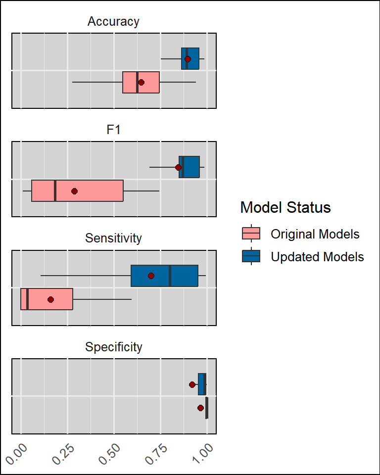

```r
# Reshape the data to long format
long.data <- ipp.models %>%
  select(common.name, Accuracy:F1) %>%
  gather(key = "Metric", value = "Value", -common.name)

long.data.old <- ipp.models.old %>%
  select(common.name, Accuracy:F1) %>%
  gather(key = "Metric", value = "Value", -common.name)

# Combine the old and new data frames, adding an identifier column
long.data$new.old <- "Updated Models"
long.data.old$new.old <- "Original Models"
combined.long <- rbind(long.data, long.data.old)

ggplot(combined.long,
         aes(x = Metric, y = Value, fill = new.old)) +
    geom_boxplot(outlier.shape = NA) +
    stat_summary(aes(group = new.old), fun = mean, fill="darkred",
                 geom = "point", shape = 21, size = 2, color = "black",
                 position = position_dodge(width = 0.75),) +
    scale_fill_manual(values = c("#FF9999", "#00659F"),
                      name = "Model Status",
                      labels = c("Original Models", "Updated Models")) +
    theme_minimal(base_size = 12) +
    theme(axis.text.x = element_text(angle = 45, hjust = 1),
          axis.text.y = element_blank(),
          axis.title = element_blank(),
          panel.background = element_rect(fill = "lightgray"),
          plot.background = element_rect(fill = "white")) +
    coord_flip() +
    facet_wrap(~Metric, ncol=1, scales="free_y")
```

#### Original Models

```r
summary(ipp.models.old)
```

```
##  common.name           state           covariate.count optimal.threshold
##  Length:32          Length:32          Min.   : 0.00   Min.   :0.2649
##  Class :character   Class :character   1st Qu.: 9.00   1st Qu.:0.4804
##  Mode  :character   Mode  :character   Median :42.50   Median :0.6114
##                                        Mean   :30.72   Mean   :0.6669
##                                        3rd Qu.:50.00   3rd Qu.:0.9460
##                                        Max.   :50.00   Max.   :1.0000
##
##     Accuracy       Sensitivity       Specificity            F1
##  Min.   :0.2766   Min.   :0.00000   Min.   :0.04218   Min.   :0.009479
##  1st Qu.:0.5487   1st Qu.:0.00000   1st Qu.:0.99603   1st Qu.:0.058968
##  Median :0.6258   Median :0.03321   Median :0.99932   Median :0.183740
##  Mean   :0.6462   Mean   :0.15896   Mean   :0.96510   Mean   :0.288013
##  3rd Qu.:0.7455   3rd Qu.:0.27887   3rd Qu.:1.00000   3rd Qu.:0.549047
##  Max.   :0.9412   Max.   :0.98264   Max.   :1.00000   Max.   :0.744135
##                                                       NA's   :9
```

#### Updated Models

```r
summary(ipp.models)
```

```
##  common.name           state           covariate.count optimal.threshold
##  Length:32          Length:32          Min.   :-1.00   Min.   :0.05115
##  Class :character   Class :character   1st Qu.:14.50   1st Qu.:0.08485
##  Mode  :character   Mode  :character   Median :42.50   Median :0.13564
##                                        Mean   :33.81   Mean   :0.26414
##                                        3rd Qu.:50.00   3rd Qu.:0.27369
##                                        Max.   :50.00   Max.   :0.94994
##
##     Accuracy       Sensitivity      Specificity            F1
##  Min.   :0.7090   Min.   :0.0000   Min.   :0.05846   Min.   :0.1739
##  1st Qu.:0.8651   1st Qu.:0.5941   1st Qu.:0.95457   1st Qu.:0.8503
##  Median :0.8916   Median :0.8018   Median :0.98729   Median :0.8690
##  Mean   :0.8953   Mean   :0.6992   Mean   :0.91913   Mean   :0.8456
##  3rd Qu.:0.9581   3rd Qu.:0.9511   3rd Qu.:0.99338   3rd Qu.:0.9596
##  Max.   :0.9874   Max.   :0.9942   Max.   :1.00000   Max.   :0.9870
##                                                      NA's   :4
```

### Summaries by Species

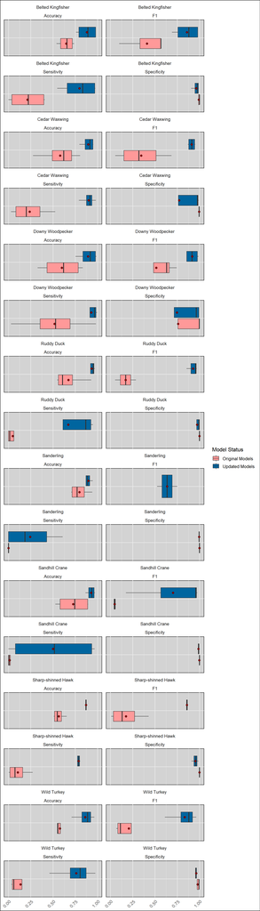

```r
ggplot(combined.long,
         aes(x = Metric, y = Value, fill = new.old)) +
    geom_boxplot(outlier.shape = NA) +
    stat_summary(aes(group = new.old), fun = mean, fill="darkred",
                 geom = "point", shape = 21, size = 2, color = "black",
                 position = position_dodge(width = 0.75),) +
    scale_fill_manual(values = c("#FF9999", "#00659F"),
                      name = "Model Status",
                      labels = c("Original Models", "Updated Models")) +
    theme_minimal(base_size = 12) +
    theme(axis.text.x = element_text(angle = 45, hjust = 1),
          axis.text.y = element_blank(),
          axis.title = element_blank(),
          panel.background = element_rect(fill = "lightgray"),
          plot.background = element_rect(fill = "white")) +
    coord_flip() +
    facet_wrap(~common.name + Metric, ncol=2, scales="free_y")
```

### Summaries by State

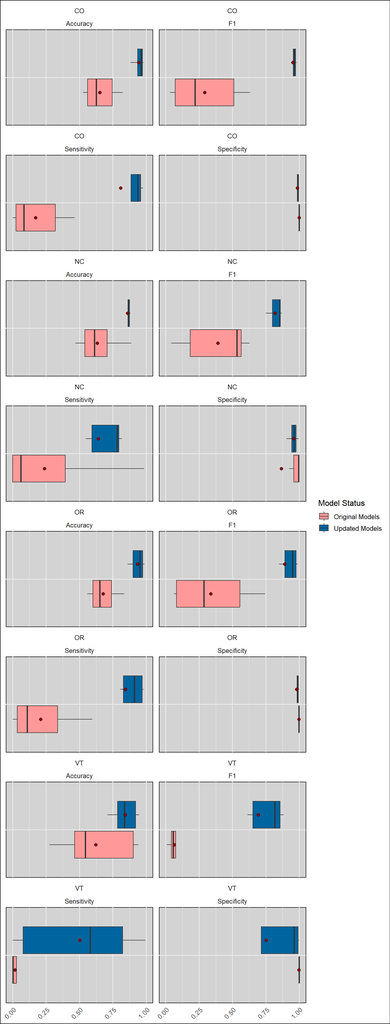

```r
# Reshape the data to long format
long.data <- ipp.models %>%
  select(state, Accuracy:F1) %>%
  gather(key = "Metric", value = "Value", -state)

long.data.old <- ipp.models.old %>%
  select(state, Accuracy:F1) %>%
  gather(key = "Metric", value = "Value", -state)

# Combine the old and new data frames, adding an identifier column
long.data$new.old <- "Updated Models"
long.data.old$new.old <- "Original Models"
combined.long <- rbind(long.data, long.data.old)

# Box plots for each state
ggplot(combined.long,
         aes(x = Metric, y = Value, fill = new.old)) +
    geom_boxplot(outlier.shape = NA) +
    stat_summary(aes(group = new.old), fun = mean, fill="darkred",
                 geom = "point", shape = 21, size = 2, color = "black",
                 position = position_dodge(width = 0.75),) +
    scale_fill_manual(values = c("#FF9999", "#00659F"),
                      name = "Model Status",
                      labels = c("Original Models", "Updated Models")) +
    theme_minimal(base_size = 12) +
    theme(axis.text.x = element_text(angle = 45, hjust = 1),
          axis.text.y = element_blank(),
          axis.title = element_blank(),
          panel.background = element_rect(fill = "lightgray"),
          plot.background = element_rect(fill = "white")) +
    coord_flip() +
    facet_wrap(~state + Metric, ncol=2, scales="free_y")
```

### Discussion

The revised models, following adjustments from [part 5](https://benton-tripp.github.io/posts/2023-10-13-sdm-benchmark-study-part-5-fitting-and-testing-ipp-models.html), exhibit improved performance with average accuracy elevating to ~90% and F1 score to ~0.85. Unlike before, Sensitivity and Specificity metrics are no longer polarized, indicating better identification of the positive class. This progress suggests that modifications to the pseudo-absence selection and model-fitting processes have positively impacted the model’s predictive accuracy. Further refinements, especially concerning pseudo-absence data, may continue to enhance the model’s performance in distinguishing between observation/absence points, fostering a more accurate representation for future analysis.